# Single-Cell RNA-seq Integration for Cell-Type-Specific Candidate Evaluation

Brian Gural, Todd Kimball, Anh Luu, Christoph D. Rau

2026-02-18

# Overview

Bulk-tissue transcriptomic data, which form a common evidence layer in GWAS candidate gene prioritization, can obscure effects that are specific to particular cell types. A gene that appears broadly expressed in bulk tissue may in fact be restricted to a small cell population, and conversely, a gene with moderate bulk expression may be highly enriched in the disease-relevant cell type.

This vignette demonstrates how to use single-cell RNA-seq (scRNA-seq) data to evaluate candidate genes identified by `locusPackRat` for cell-type-specific expression. Specifically, we show how to:

1. Load a reference scRNA-seq dataset
2. Score candidate gene sets using Seurat’s `AddModuleScore()`
3. Visualize module scores across cell types
4. Use the results to refine candidate gene prioritization

A bundled mini Seurat object (200 cells, 4 cardiac cell types) is used here for demonstration. For real analyses, substitute your own scRNA-seq reference (see the Tabula Muris example at the end of this vignette).

# Prerequisites

```r
# Core packages
library(locusPackRat)
library(data.table)

# scRNA-seq analysis
library(Seurat)     # install from CRAN: install.packages("Seurat")
```

```r
library(ggplot2)
```

# Step 1: Create a locusPackRat Project

First, we create a temporary locusPackRat project with candidate genes from a cardiac hypertrophy study. These five genes will be evaluated for cell-type specificity.

```r
# Define candidate genes from a cardiac QTL study
cardiac_candidates <- c("Cisd2", "Pdlim5", "Manba", "Fhod3", "Myh7")

# Create a temporary project directory
project_dir <- file.path(tempdir(), "sc_demo_project")

# Initialize a locusPackRat project with these genes
gene_input <- data.frame(gene_symbol = cardiac_candidates)
initPackRat(
  data = gene_input,
  mode = "gene",
  species = "mouse",
  genome = "mm39",
  project_dir = project_dir,
  force = TRUE
)
```

```
#> Initializing locusPackRat project...
#> Note: All data added to this project must use the mm39 genome build. Mixing genome builds will cause incorrect coordinate matching. Use rtracklayer::liftOver() to convert coordinates if needed.
#> Processing gene list...
#>   Matched all 5 genes to coordinates
#> Generating orthology information...
#> Saved gene data to /work/appscr/r/bgural/RtmpwHwfjY/sc_demo_project/.locusPackRat/input/genes.csv
#> Saved orthology data to /work/appscr/r/bgural/RtmpwHwfjY/sc_demo_project/.locusPackRat/input/orthology.csv
#> Created config file: /work/appscr/r/bgural/RtmpwHwfjY/sc_demo_project/.locusPackRat/config.json
#>
#> locusPackRat project initialized successfully!
#> Mode: gene | Species: mouse | Genome: mm39
#> Processed 5 genes
```

```r
# Show the initialized gene table
master_genes <- fread(file.path(project_dir, ".locusPackRat", "input", "genes.csv"))
print(master_genes[, .(gene_symbol, chr, start, end)])
```

```
#>    gene_symbol   chr     start       end
#>         <char> <int>     <int>     <int>
#> 1:       Cisd2     3 135112173 135129686
#> 2:       Fhod3    18  24841680  25266558
#> 3:       Manba     3 135191372 135277165
#> 4:        Myh7    14  55208141  55232083
#> 5:      Pdlim5     3 141945351 142101454
```

# Step 2: Load a Reference scRNA-seq Dataset

We load the bundled mini Seurat object, which contains 200 cells across four cardiac cell types (cardiomyocyte, fibroblast, endothelial, immune) with pre-computed PCA and UMAP embeddings.

```r
# Load the bundled mini Seurat object
seurat_path <- system.file("extdata", "mini_heart_seurat.rds",
                           package = "locusPackRat")
# Fallback for devtools/development builds where inst/ isn't installed yet
if (!nzchar(seurat_path)) {
  seurat_path <- file.path("..", "inst", "extdata", "mini_heart_seurat.rds")
}

if (!file.exists(seurat_path)) {
  message("mini_heart_seurat.rds not found -- skipping remaining chunks.")
  knitr::opts_chunk$set(eval = FALSE)
} else {
  heart_seurat <- readRDS(seurat_path)

  # Inspect the object
  heart_seurat

  # Cell type composition
  table(heart_seurat$cell_type)
}
```

```
#>
#> cardiomyocyte   endothelial    fibroblast        immune
#>            50            50            50            50
```

For a real analysis, you would load a full scRNA-seq reference such as Tabula Muris. The code below is provided as a reference but not executed:

```r
# Download Tabula Muris heart data (10X Genomics)
# Data available from: https://tabula-muris.ds.czbiohub.org/
heart_data <- Read10X(data.dir = "path/to/tabula_muris/Heart-10X_P7_4/")
heart_seurat <- CreateSeuratObject(counts = heart_data, project = "TabulaMuris_Heart",
                                   min.cells = 3, min.features = 200)
heart_seurat <- NormalizeData(heart_seurat)
heart_seurat <- FindVariableFeatures(heart_seurat, nfeatures = 2000)
heart_seurat <- ScaleData(heart_seurat)
heart_seurat <- RunPCA(heart_seurat)
heart_seurat <- FindNeighbors(heart_seurat, dims = 1:20)
heart_seurat <- FindClusters(heart_seurat, resolution = 0.5)
heart_seurat <- RunUMAP(heart_seurat, dims = 1:20)
```

# Step 3: Score Candidate Genes with AddModuleScore

Seurat’s `AddModuleScore()` calculates per-cell enrichment scores for a set of genes, controlling for expression level and gene set size. This allows us to ask: “Are our candidate genes collectively enriched in specific cell types?”

```r
# Only score genes that are present in the dataset
candidates_in_data <- intersect(cardiac_candidates, rownames(heart_seurat))
cat("Candidates found in dataset:", paste(candidates_in_data, collapse = ", "), "\n")
```

```
#> Candidates found in dataset: Cisd2, Pdlim5, Manba, Fhod3, Myh7
```

```r
# Define gene lists for module scoring
candidate_list <- list(cardiac_candidates = candidates_in_data)

# Calculate module scores
# For small gene panels (e.g., bundled demo data), reduce ctrl and nbin
# so that control gene sampling does not exceed available genes per bin
n_features <- nrow(heart_seurat)
use_ctrl <- if (n_features < 200) 5 else 100
use_nbin <- if (n_features < 200) 5 else 24
heart_seurat <- AddModuleScore(
  object = heart_seurat,
  features = candidate_list,
  ctrl = use_ctrl,
  nbin = use_nbin,
  name = "candidate_score"
)

# The score is added as a metadata column: "candidate_score1"
# Higher scores indicate stronger collective expression of the candidate genes
summary(heart_seurat$candidate_score1)
```

```
#>    Min. 1st Qu.  Median    Mean 3rd Qu.    Max.
#> -3.4598 -1.9638 -1.0709 -1.0066 -0.1324  1.8566
```

# Step 4: Visualize Module Scores by Cell Type

## UMAP Visualization

The module score projected onto the UMAP embedding reveals which cell populations show enriched expression of the candidate gene set.

[figure not shown]

UMAP colored by candidate gene module score. Warmer colors indicate higher collective expression.

```r
FeaturePlot(
  heart_seurat,
  features = "candidate_score1",
  cols = c("lightgrey", "blue", "red"),
  pt.size = 1.5
) +
  ggtitle("Candidate Gene Module Score") +
  theme(plot.title = element_text(hjust = 0.5))
```

## Violin Plot by Cell Type

A violin plot directly compares the distribution of module scores across cell types.

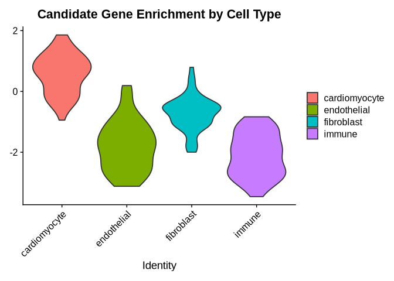

Module score distribution by cell type. Cardiomyocytes show the highest enrichment.

```r
VlnPlot(
  heart_seurat,
  features = "candidate_score1",
  group.by = "cell_type",
  pt.size = 0
) +
  ggtitle("Candidate Gene Enrichment by Cell Type") +
  theme(axis.text.x = element_text(angle = 45, hjust = 1))
```

## Individual Gene Expression

Examining expression of individual candidate genes across cell types identifies which candidates drive the module score.

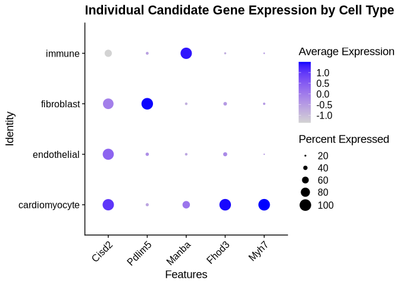

Dot plot of individual candidate genes by cell type. Size = percent expressing; color = mean expression.

```r
# Use only candidates present in the data
genes_to_plot <- intersect(cardiac_candidates, rownames(heart_seurat))

DotPlot(
  heart_seurat,
  features = genes_to_plot,
  group.by = "cell_type"
) +
  RotatedAxis() +
  ggtitle("Individual Candidate Gene Expression by Cell Type")
```

# Step 5: Quantify Cell-Type Specificity

Calculate summary statistics for candidate gene expression across cell types to produce a quantitative ranking.

```r
# Extract expression matrix for candidate genes
# Use layer= for Seurat v5 compatibility, fall back to slot= for v4
expr_matrix <- tryCatch(
  GetAssayData(heart_seurat, layer = "data"),
  error = function(e) GetAssayData(heart_seurat, slot = "data")
)
candidates_in_data <- intersect(cardiac_candidates, rownames(expr_matrix))

if (length(candidates_in_data) > 0) {
  # Calculate mean expression per cell type per gene
  cell_type_expr <- data.table(
    cell_type = heart_seurat$cell_type,
    as.data.table(t(as.matrix(expr_matrix[candidates_in_data, , drop = FALSE])))
  )

  # Aggregate by cell type
  mean_expr <- cell_type_expr[, lapply(.SD, mean), by = cell_type,
                               .SDcols = candidates_in_data]

  # Calculate percentage of cells expressing each gene (> 0) per cell type
  pct_expr <- cell_type_expr[, lapply(.SD, function(x) mean(x > 0) * 100),
                              by = cell_type, .SDcols = candidates_in_data]

  cat("Mean expression by cell type:\n")
  print(mean_expr)

  cat("\nPercent cells expressing (> 0) by cell type:\n")
  print(pct_expr)
}
```

```
#> Mean expression by cell type:
#>        cell_type    Cisd2   Pdlim5    Manba     Fhod3      Myh7
#>           <char>    <num>    <num>    <num>     <num>     <num>
#> 1: cardiomyocyte 5.309071 1.237711 2.930222 5.8097861 5.7916169
#> 2:    fibroblast 4.482631 5.845352 1.124158 1.4648019 1.0245894
#> 3:   endothelial 4.873538 1.442376 1.151545 1.7073730 0.7211630
#> 4:        immune 2.944514 1.202297 5.340340 0.9442931 0.7846961
#>
#> Percent cells expressing (> 0) by cell type:
#>        cell_type Cisd2 Pdlim5 Manba Fhod3  Myh7
#>           <char> <num>  <num> <num> <num> <num>
#> 1: cardiomyocyte    98     30    66   100   100
#> 2:    fibroblast    92    100    26    34    24
#> 3:   endothelial    96     32    26    38    16
#> 4:        immune    64     28    98    22    18
```

# Step 6: Integrate Results into locusPackRat

The cell-type specificity results can be formatted and added to a locusPackRat project as an additional evidence layer.

```r
# Build a summary table of cell-type expression for each candidate
cell_type_names <- sort(unique(heart_seurat$cell_type))

specificity_summary <- data.table(
  gene_symbol = candidates_in_data,
  cardiomyocyte_expr = as.numeric(mean_expr[cell_type == "cardiomyocyte",
                                             ..candidates_in_data]),
  fibroblast_expr = as.numeric(mean_expr[cell_type == "fibroblast",
                                          ..candidates_in_data]),
  endothelial_expr = as.numeric(mean_expr[cell_type == "endothelial",
                                           ..candidates_in_data]),
  immune_expr = as.numeric(mean_expr[cell_type == "immune",
                                      ..candidates_in_data])
)

# Calculate a simple specificity index:
# ratio of cardiomyocyte expression to mean of all other cell types
specificity_summary[, cardiomyocyte_specificity :=
  cardiomyocyte_expr / rowMeans(.SD),
  .SDcols = c("fibroblast_expr", "endothelial_expr", "immune_expr")]

print(specificity_summary)
```

```
#>    gene_symbol cardiomyocyte_expr fibroblast_expr endothelial_expr immune_expr
#>         <char>              <num>           <num>            <num>       <num>
#> 1:       Cisd2           5.309071        4.482631         4.873538   2.9445143
#> 2:      Pdlim5           1.237711        5.845352         1.442376   1.2022968
#> 3:       Manba           2.930222        1.124158         1.151545   5.3403399
#> 4:       Fhod3           5.809786        1.464802         1.707373   0.9442931
#> 5:        Myh7           5.791617        1.024589         0.721163   0.7846961
#>    cardiomyocyte_specificity
#>                        <num>
#> 1:                 1.2948236
#> 2:                 0.4373525
#> 3:                 1.1542299
#> 4:                 4.2340566
#> 5:                 6.8663130
```

```r
# Add to locusPackRat project
addRatTable(
  data = specificity_summary,
  table_name = "sc_cell_type_expression",
  abbreviation = "sc",
  link_type = "gene",
  link_by = "gene_symbol",
  project_dir = project_dir
)
```

```
#> Adding supplementary table to mouse mm39 project...
#> Linking data by gene_symbol...
#> Saved supplementary table to /work/appscr/r/bgural/RtmpwHwfjY/sc_demo_project/.locusPackRat/supplementary/sc_cell_type_expression.csv
#> Linked 5 of 5 input rows
#> Updated config file
```

## Project State After Integration

```r
# Show all tables in the project
listPackRatTables(project_dir)
```

```
#> Found 1 supplementary table(s):
#>   - sc_cell_type_expression: 5 rows with 7 cols, linked by 'gene_symbol'
#>                 table_name table_abbr link_type     link_by n_rows n_cols
#>                     <char>     <char>    <char>      <char>  <int>  <int>
#> 1: sc_cell_type_expression         sc      gene gene_symbol      5      7
#>    date_added
#>        <char>
#> 1: 2026-02-18
```

The single-cell evidence layer is now stored alongside any other annotations in the project. It can be exported via `buildExcel()` or used for downstream prioritization.

# Tips and Considerations

1. **Reference Dataset Selection**: Choose a scRNA-seq dataset from the tissue most relevant to your phenotype. Tabula Muris provides broad tissue coverage; tissue-specific atlases (e.g., the Human Cell Atlas) may offer finer resolution.
2. **Species Matching**: If your locusPackRat project uses mouse gene symbols, ensure the scRNA-seq reference also uses mouse symbols. For cross-species comparisons, use the orthology table generated by `initPackRat()`.
3. **Module Score Interpretation**: `AddModuleScore()` returns relative scores that control for average expression level. A high score means the gene set is more expressed than expected given the cells’ overall transcriptional activity. Scores are most useful for comparing across cell types within the same dataset, not across datasets.
4. **Statistical Testing**: For formal statistical comparisons of module scores between cell types, consider using a Wilcoxon rank-sum test or permutation testing rather than relying solely on visual inspection.
5. **Scaling to Many Loci**: For studies with many candidate loci, you can create separate module scores for each locus and compare cell-type enrichment patterns across loci to identify shared or locus-specific cell type involvement.
6. **Single-Cell QTL Data**: As single-cell eQTL (sceQTL) datasets grow, consider querying these through `queryOpenTargetsQTL()` with `study_types = c("sceqtl", "scpqtl")` for variant-level cell-type-specific evidence that complements the expression-based approach shown here.